# AI in the workplace - Appendix A

Workforce Analytics

Assignment 2 - Group 2

| 01609836 | **Kyburz Jean-Luc** |
| --- | --- |
| 01023288 | **Morelli Dario** |
| 01816109 | **Schaaff Alina** |
| 01831190 | **Villani Francesco** |
| 01633983 | **Wheatley David** |

# Table of Contents

## Task Vectorization

In this notebook we explore the first approach mentioned in our report.

Using NLP, tasks are reduced to a collection of verbs which are then vectorized, to obtain relative meanings, and then grouped and inspected using the vector cosine similarity to provide the required insight.

```python
#Import standard libraries
import pandas as pd
import numpy as np
import itertools
import operator

#Import visualisation libraries
import matplotlib.pyplot as plt
import seaborn as sns
from wordcloud import WordCloud

# import machine learning libraries
from sklearn.decomposition import PCA
from sklearn.preprocessing import StandardScaler
from sklearn.cluster import KMeans
from kneed import KneeLocator

# Import NLP libraries
import spacy
from spacy.matcher import Matcher
from spacy.strings import StringStore
import re
from collections import defaultdict
```

## Inspect the tasks detailed in the datafile

We begin by investigating the data and looking at the key words that have been used in the task descriptions

### Import the data and group by role

```python
#Import the data files
jobs = pd.read_excel('/Users/MacUser/Dropbox/Study/Imperial/WA/Assignment 2/O_NET Task Statements.xlsx')
jobs.head()
```

|  | O*NET-SOC Code | Title | Task ID | Task | Task Type | Incumbents Responding | Date | Domain Source | Main Task Verb |
| --- | --- | --- | --- | --- | --- | --- | --- | --- | --- |
| 0 | 11-1011.00 | Chief Executives | 8823 | Direct or coordinate an organization's financi... | Core | 87.0 | 07/2014 | Incumbent | Direct |
| 1 | 11-1011.00 | Chief Executives | 8831 | Appoint department heads or managers and assig... | Core | 87.0 | 07/2014 | Incumbent | Appoint |
| 2 | 11-1011.00 | Chief Executives | 8825 | Analyze operations to evaluate performance of ... | Core | 87.0 | 07/2014 | Incumbent | Analyze |
| 3 | 11-1011.00 | Chief Executives | 8826 | Direct, plan, or implement policies, objective... | Core | 87.0 | 07/2014 | Incumbent | Direct, |
| 4 | 11-1011.00 | Chief Executives | 8827 | Prepare budgets for approval, including those ... | Core | 87.0 | 07/2014 | Incumbent | Prepare |

Grouping the tasks by job title and combining the task descriptions we can create a job description for each role

```python
#Group the roles together to obtain a job descirption
roles = jobs.groupby(['Title'])['Task'].apply(','.join).reset_index()
roles.set_index('Title', inplace=True)
roles.head()
```

| Title | Task |
| --- | --- |
| Accountants | Develop, maintain, and analyze budgets, prepar... |
| Actors | Collaborate with other actors as part of an en... |
| Actuaries | Ascertain premium rates required and cash rese... |
| Acupuncturists | Insert needles to provide acupuncture treatmen... |
| Acute Care Nurses | Perform emergency medical procedures, such as ... |

```python
#Inspect the content of a specific role
roles.loc['Accountants', 'Task']
```

```
'Develop, maintain, and analyze budgets, preparing periodic reports that compare budgeted costs to actual costs.,Prepare, examine, or analyze accounting records, financial statements, or other financial reports to assess accuracy, completeness, and conformance to reporting and procedural standards.,…
```

### Pre-process - Remove stop words and lemmatize the task descriptions

Removing the stop words and taking the lemmatized form allows us to analyse which words are used most frequently. Using the lemmatized from ensures words with a common root E.g. say, said, saying are considered as the same word.

```python
#Instantiate a spaCy model
nlp = spacy.load('en_core_web_lg')
all_stopwords = nlp.Defaults.stop_words
```

```python
#define a function to remove stop words
def remove_stopwords(text):
    doc = nlp(text)
    words=[w.lemma_ for w in doc if (not w.is_stop and not w.is_punct and not w.like_num)]

    #Noting not all punctuation has been removed a regex function is added
    new_words = []
    for word in words:
        w = re.sub(r'[^\w\s]','',word) #remove everything except words and space#how
                                        #to remove underscore as well
        w = re.sub(r'\_','',w)
        new_words.append(w)
    return new_words
```

```python
# Apply the remove_stopwords function to the dataframe
roles['stop_words'] = roles.apply(lambda roles: remove_stopwords(roles['Task']),axis=1)

#Display the dataframe
roles.head()
```

| Title | Task | stop_words |
| --- | --- | --- |
| Accountants | Develop, maintain, and analyze budgets, prepar... | [develop, maintain, analyze, budget, prepare, ... |
| Actors | Collaborate with other actors as part of an en... | [collaborate, actor, ensemble, Portray, interp... |
| Actuaries | Ascertain premium rates required and cash rese... | [ascertain, premium, rate, require, cash, rese... |
| Acupuncturists | Insert needles to provide acupuncture treatmen... | [insert, needle, provide, acupuncture, treatme... |
| Acute Care Nurses | Perform emergency medical procedures, such as ... | [perform, emergency, medical, procedure, basic... |

### Visualise the most common words

To allow the common words to be easily assessed the following code performed a basic count and presents the information as both a bar chart and word cloud.

```python
#Combine all the words into a single list
combined = []
for n in range(len(roles)):
    combined += roles.iloc[n,1]
```

```python
# Create the defaultdict: total_word_count to store the quantity of each word
word_count = defaultdict(int)

for word in combined:
        word_count[word] += 1

df_word_count = pd.DataFrame.from_dict(word_count, orient='index')
df_word_count.columns=['count']
df_word_count.sort_values(by=['count'], ascending=False, inplace=True)
df_word_count.head()
```

|  | count |
| --- | --- |
| equipment | 2137 |
| material | 1390 |
| system | 1124 |
| work | 991 |
| product | 955 |

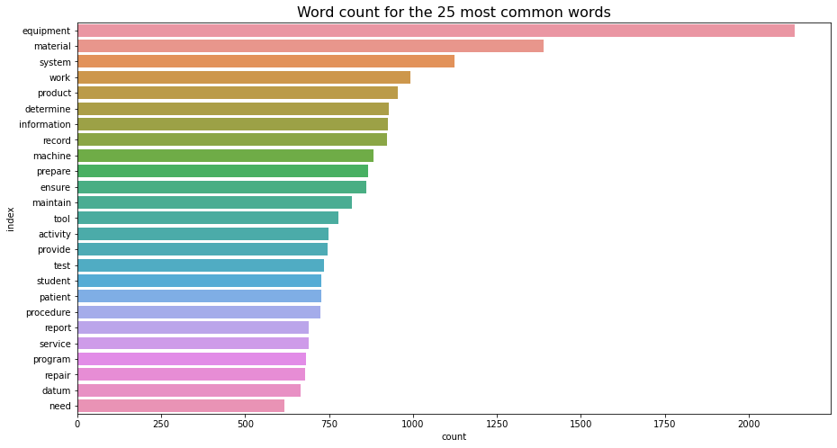

```python
#Subset the dataframe
df_word_count5=df_word_count[:25]

#Generate the histogram
plt.figure(figsize=(15,8))
sns.barplot(x='count',y='index', data = df_word_count5.reset_index())

plt.title('Word count for the 25 most common words', loc='center', fontsize=16)
plt.show()
```

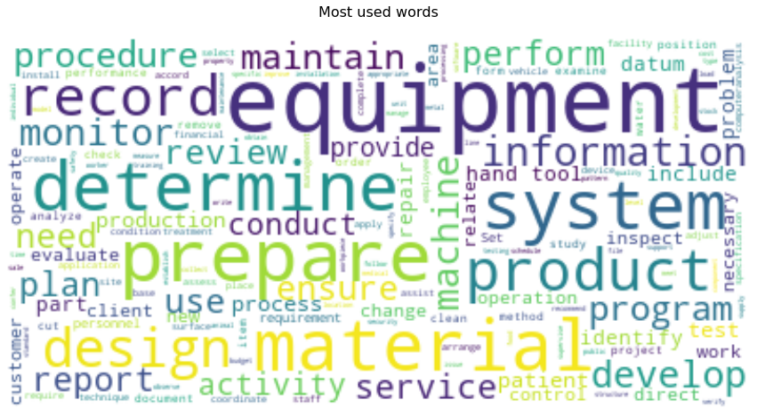

```python
# Alternatively we could display as a wordcloud
text = ' '.join(combined)

wordcloud = WordCloud(max_font_size=50, max_words=250, background_color="white").generate(text)
plt.figure(figsize=(15,15))
plt.imshow(wordcloud, interpolation="bilinear")

plt.title('Most used words\n', loc='center', fontsize=16)
plt.axis("off")
plt.show()
```

## Investigating the action verbs

To understand the activties performed within each task we want to extract the verbs / action words. Using the tokenization within from the spacy library we are able to list the part of speech for every word in a sentence.

### Investigate the part of speech tags for 1 specific task

```python
#Looking at a specific task
task = jobs.loc[2,'Task']
print(task+"\n\n")

# Process the text
doc = nlp(task)

# Iterate over the tokens
print('{:<15}{:<10}{:<10}{:<12}'.format('Text','POS','Tag','Explanation'))
for token in doc:
    #Print the text and predicted POS tag
    print('{:<15}{:<10}{:<10}{:<12}'.format(token.text,token.pos_,token.tag_, spacy.explain(token.tag_)))
```

```
Analyze operations to evaluate performance of a company or its staff in meeting objectives or to determine areas of potential cost reduction, program improvement, or policy change.


Text           POS       Tag       Explanation
Analyze        VERB      VB        verb, base form
operations     NOUN      NNS       noun, plural
to             PART      TO        infinitival "to"
evaluate       VERB      VB        verb, base form
performance    NOUN      NN        noun, singular or mass
of             ADP       IN        conjunction, subordinating or preposition
a              DET       DT        determiner
company        NOUN      NN        noun, singular or mass
or             CCONJ     CC        conjunction, coordinating
its            DET       PRP$      pronoun, possessive
staff          NOUN      NN        noun, singular or mass
in             ADP       IN        conjunction, subordinating or preposition
meeting        VERB      VBG       verb, gerund or present participle
objectives     NOUN      NNS       noun, plural
or             CCONJ     CC        conjunction, coordinating
to             PART      TO        infinitival "to"
determine      VERB      VB        verb, base form
areas          NOUN      NNS       noun, plural
of             ADP       IN        conjunction, subordinating or preposition
potential      ADJ       JJ        adjective
cost           NOUN      NN        noun, singular or mass
reduction      NOUN      NN        noun, singular or mass
,              PUNCT     ,         punctuation mark, comma
program        NOUN      NN        noun, singular or mass
improvement    NOUN      NN        noun, singular or mass
,              PUNCT     ,         punctuation mark, comma
or             CCONJ     CC        conjunction, coordinating
policy         NOUN      NN        noun, singular or mass
change         NOUN      NN        noun, singular or mass
.              PUNCT     .         punctuation mark, sentence closer
```

### Process the verbs in each task

Having identified the verbs we then need to extract them as a separate list using the following function

```python
#Create a function to extract the verbs
def get_verbs(text):
    verbs= []
    doc = nlp(text)
    for token in doc:
        #Extract only the words with tag =="VB" - 'verb, gerund or present participle'
        if token.tag_ == "VB":
            verbs.append(token.lemma_)

    #Noting not all punctuation has been removed a regex function is added
    new_words = []
    for word in verbs:
        w = re.sub(r'[^\w\s]','',word) #remove everything except words and space#how
                                        #to remove underscore as well
        w = re.sub(r'\_','',w)
        new_words.append(w)

    return(new_words)

# Apply the get verbs function
roles['verbs'] = roles.apply(lambda roles: get_verbs(roles['Task']),axis=1)

#Display the dataframe
roles.head(10)
```

| Title | Task | stop_words | verbs |
| --- | --- | --- | --- |
| Accountants | Develop, maintain, and analyze budgets, prepar... | [develop, maintain, analyze, budget, prepare, ... | [develop, maintain, analyze, examine, analyze,... |
| Actors | Collaborate with other actors as part of an en... | [collaborate, actor, ensemble, Portray, interp... | [collaborate, interpret, entertain, inform, in... |
| Actuaries | Ascertain premium rates required and cash rese... | [ascertain, premium, rate, require, cash, rese... | [ascertain, ensure, help, administer, help, de... |
| Acupuncturists | Insert needles to provide acupuncture treatmen... | [insert, needle, provide, acupuncture, treatme... | [insert, provide, follow, make, promote, resto... |
| Acute Care Nurses | Perform emergency medical procedures, such as ... | [perform, emergency, medical, procedure, basic... | [perform, result, collaborate, plan, coordinat... |
| Adapted Physical Education Specialists | Provide adapted physical education services to... | [provide, adapt, physical, education, service,... | [provide, adapt, improve, maintain, document, ... |
| Adhesive Bonding Machine Operators and Tenders | Align and position materials being joined to e... | [align, position, material, join, ensure, accu... | [align, position, ensure, detect, report, reso... |
| Administrative Law Judges, Adjudicators, and Hearing Officers | Prepare written opinions and decisions.,Monito... | [prepare, write, opinion, decision, Monitor, d... | [prepare, direct, ensure, analyze, prepare, de... |
| Administrative Services Managers | Monitor the facility to ensure that it remains... | [monitor, facility, ensure, remain, safe, secu... | [monitor, ensure, review, ensure, distribute, ... |
| Adult Basic and Secondary Education and Literacy Teachers and Instructors | Observe and evaluate students' work to determi... | [observe, evaluate, student, work, determine, ... | [observe, evaluate, determine, make, determine... |

From this we observe a total of 1137 verbs have been used which we can combine into a list for which we print the first 200 characters

```python
#Combine all the words into a single list
combined_verbs = []
for n in range(len(roles)):
    combined_verbs += roles.iloc[n,2]

verbs_list = list(set(combined_verbs))

print('In total there are {} verbs used'.format(len(verbs_list)))
```

```
In total there are 1137 verbs used
```

```python
# convert the list to a string
verb_string = ' '.join(verbs_list)
# Print the first 200 charecters
verb_string[:200]
```

```
' disinfect logs hold instruct test assure alert project illustrate circulate liquefy manufacture maneuver lap assign facilitate rule doctor redistribute gauge preserve attach reinforce narrate weigh d'
```

### Use the word vectors and find the cosine similarity

A word vector is a 300 dimensional representation a word. Words that have similar meaning appear closer together of this vector space. Looking at the cosine similarity of verbs we can assess how similar they are in meaning and begin grouping them

```python
def get_word_vectors(verbs_list):
    # converts a list of words into their word vectors
    return [nlp(word).vector for word in verbs_list]
```

Using principal component analysis we can now represent this word similarity on a 2D chart

```python
word_vecs_2d[:2,0]
```

```
array([0.41787243, 3.61175767])
```

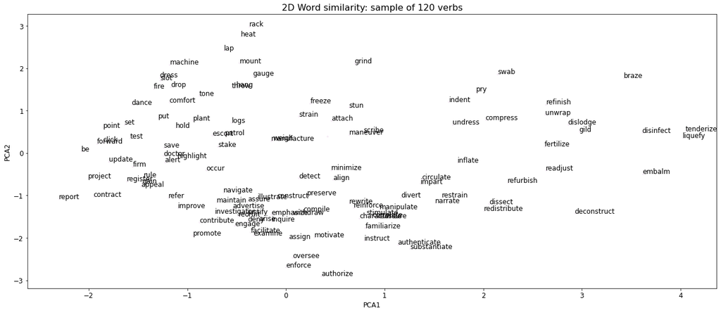

```python
# intialise pca model and tell it to project data down onto 2 dimensions
pca = PCA(n_components=2)
n=120

# fit and transform the the data
pca.fit(get_word_vectors(verbs_list))
word_vecs_2d = pca.transform(get_word_vectors(verbs_list))

# create a plot
plt.figure(tight_layout=True)
plt.figure(figsize=(22,9))
plt.scatter(word_vecs_2d[:n,0], word_vecs_2d[:n,1], s =7, alpha=0.05, color='purple')

# for each word and coordinate pair: draw the text on the plot
for word, coord in zip(verbs_list[:n], word_vecs_2d[:n]):
    x, y = coord
    plt.text(x, y, word, size= 12)

# show the plot
plt.xlabel("PCA1")
plt.ylabel("PCA2")
plt.title('2D Word similarity: sample of 120 verbs', loc='center', fontsize=16)
plt.show()
```

### Initial Kmean clustering to check the accuracy of our vectorization

Using K-means we can cluster the verbs into 4 groups and represent on a 2D plot.

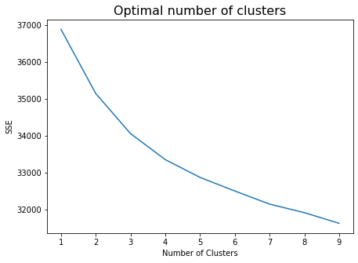

```python
kmeans_settings ={
    'init': 'k-means++',
    'n_init': 10,
    'max_iter': 300,
    'random_state': 7,}

sse = []

for k in range(1,10):
    kmeans = KMeans(n_clusters = k, **kmeans_settings)
    kmeans.fit(get_word_vectors(verbs_list))
    sse.append(kmeans.inertia_)

plt.figure(figsize = (7,5))
plt.plot(range(1, 10), sse)
plt.xticks(range(1, 10))
plt.xlabel('Number of Clusters')
plt.ylabel('SSE')
plt.title('Optimal number of clusters', loc='center', fontsize=16)
plt.show()
```

```python
knee_locator = KneeLocator(range(1,10), sse, curve = 'convex', direction = 'decreasing')
knee_locator.elbow
```

```
4
```

```python
kmeans = KMeans(n_clusters=4, random_state=7,init ='k-means++')
labels = kmeans.fit_predict(get_word_vectors(verbs_list))
```

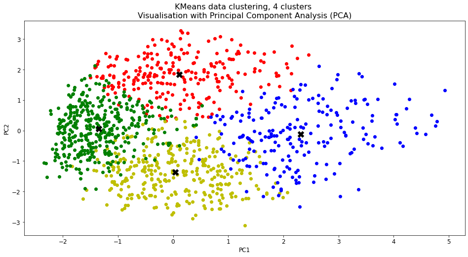

```python
pca = PCA(n_components=2)
pca_components = pca.fit_transform(get_word_vectors(verbs_list))

plt.figure(figsize=(16,8))

font = {'family' :'sans-serif',"size"  : 12}
plt.rc('font', **font)

for l, c in zip(list(range(6)), ["r", "y", 'b', 'g']):
    #plots the observations
    plt.scatter(
        pca_components[np.argwhere(labels==l),0],
        pca_components[np.argwhere(labels==l),1],
        c=c
    )
    #plots the centroid
    centroid = pca.transform([kmeans.cluster_centers_[l]])
    plt.plot(
        centroid[:,0],
        centroid[:,1],
        c=c,
        marker="x",
        markeredgecolor='k',
        markeredgewidth=5,
        markersize=10
    )

plt.title("KMeans data clustering, 4 clusters \nVisualisation with Principal Component Analysis (PCA)", fontsize = 16)
plt.xlabel("PC{}".format(1))
plt.ylabel("PC{}".format(2))
```

#### Inspect the content of each cluster

```python
d = {'Verbs':verbs_list,'Category':labels}
df_clusters = pd.DataFrame(d)
```

```python
cat0 = df_clusters[df_clusters['Category']==0]
cat0_string = ' '.join(cat0['Verbs'].tolist())
cat0_string
```

```
'maneuver lap gauge attach weigh mount swab tone strain pry rack dress slot heat freeze hang comfort throw machine grind stun casket pinch seam lather spark tilt nail climb rig skid splice size handle stucco burn pull hand scrape polish brush floor bolt switch shrink tighten mask chill wrap trim dra…
```

```python
cat1 = df_clusters[df_clusters['Category']==1]
cat1_string = ' '.join(cat1['Verbs'].tolist())
cat1_string
```

```
'instruct assure illustrate manufacture assign facilitate preserve reinforce detect inquire construct emphasize align oversee arise withdraw navigate advertise minimize rewrite engage authenticate reassure maintain justify examine occur enforce recruit correlate restrain stimulate authorize deny imp…
```

```python
cat2 = df_clusters[df_clusters['Category']==2]
cat2_string = ' '.join(cat2['Verbs'].tolist())
cat2_string
```

```
'disinfect circulate liquefy redistribute narrate braze refurbish inflate dissect refinish scribe embalm unwrap compress tenderize dislodge gild indent deconstruct readjust fertilize undress extrude solidify straighten rebase shelve amuse officiate reopen tabulate digitize impregnate sharpen engrave…
```

```python
cat3 = df_clusters[df_clusters['Category']==3]
cat3_string = ' '.join(cat3['Verbs'].tolist())
cat3_string
```

```
' logs hold test alert project rule doctor fire escort highlight plant update patrol stake forward firm report contract click set drop gain put register dance refer appeal save point be avoid reach ask know view catch have answer clear laugh become scale show train like pose repressurize deal mail b…
```